# DataKwip EDA notebook- Mohini and Nina

```python
%matplotlib inline
import requests
import numpy as np
import pandas as pd # pandas
import missingno as msno
import matplotlib.pyplot as plt # module for plotting
from statsmodels.tsa.seasonal import seasonal_decompose
import seaborn as sns
import datetime as dt # module for manipulating dates and times
from scipy import stats
```

```python
df1 = pd.read_excel('D:/Capstone/Cleaned files/MasterFile_SelectDates_V3_BackfilledData.xlsx', skip_blank_lines=True, delim_whitespace=True)
```

```python
df1.head()
```

|  | Timestamp | CompAmps | Dat_SetPt | Discharge_Temp | DuctStatic_SetPt | DuctStatic | East_Temp | Econ_Pos | Fan_Hz_call | Mixed_Temp | ... | West_Temp | Outside_Air_Temp | Outside_Rel_Humidity | CompRelayStatus | Loader2Status | SupplyFanStatus | VAVEnableRelayStatus | VAVHeatEnableStatus | Loader1sTATUS | UnoccupiedLimit |
| --- | --- | --- | --- | --- | --- | --- | --- | --- | --- | --- | --- | --- | --- | --- | --- | --- | --- | --- | --- | --- | --- |
| 0 | 2016-08-01 00:00:00 | 0.0 | 55.0 | 75.7 | 1.0 | 0.91 | 73.2 | 5.0 | 20.0 | 77.7 | ... | 75.7 | 78.2 | 100.0 | False | False | True | True | False | False | False |
| 1 | 2016-08-01 01:00:00 | 0.0 | 55.0 | 75.4 | 1.0 | 0.08 | 77.6 | 0.0 | 20.0 | 77.6 | ... | 79.9 | 77.3 | 100.0 | False | False | False | False | False | False | False |
| 2 | 2016-08-01 02:00:00 | 0.0 | 55.0 | 77.0 | 1.0 | 0.08 | 78.5 | 0.0 | 20.0 | 77.6 | ... | 80.6 | 76.4 | 100.0 | False | False | False | False | False | False | False |
| 3 | 2016-08-01 03:00:00 | 60.0 | 55.0 | 54.0 | 1.0 | 1.00 | 70.6 | 0.0 | 20.0 | 77.6 | ... | 74.3 | 75.6 | 100.0 | False | False | True | True | False | False | False |
| 4 | 2016-08-01 04:00:00 | 47.0 | 55.0 | 59.7 | 1.0 | 1.06 | 71.2 | 0.0 | 20.0 | 77.9 | ... | 74.5 | 75.1 | 100.0 | False | False | True | True | False | False | False |

5 rows × 25 columns

```python
df1 = df1.set_index(['Timestamp'])
```

```python
len(df1)
```

```
8760
```

#### Create a second DataFrame object containing the columns in the dataset and print the DataFrame to see the contents

```python
columns = pd.DataFrame(list(df1.columns.values))
columns
```

|  | 0 |
| --- | --- |
| 0 | CompAmps |
| 1 | Dat_SetPt |
| 2 | Discharge_Temp |
| 3 | DuctStatic_SetPt |
| 4 | DuctStatic |
| 5 | East_Temp |
| 6 | Econ_Pos |
| 7 | Fan_Hz_call |
| 8 | Mixed_Temp |
| 9 | NorthTemp |
| 10 | Reset_Sensor |
| 11 | Return_temp |
| 12 | South_Temp |
| 13 | Space_Temp |
| 14 | West_Temp |
| 15 | Outside_Air_Temp |
| 16 | Outside_Rel_Humidity |
| 17 | CompRelayStatus |
| 18 | Loader2Status |
| 19 | SupplyFanStatus |
| 20 | VAVEnableRelayStatus |
| 21 | VAVHeatEnableStatus |
| 22 | Loader1sTATUS |
| 23 | UnoccupiedLimit |

```python
#created a DataFrame of the data type of each column and print the DataFrame to see the contents
data_types = pd.DataFrame(df1.dtypes,columns=['Data Type'])
data_types
```

|  | Data Type |
| --- | --- |
| CompAmps | float64 |
| Dat_SetPt | float64 |
| Discharge_Temp | float64 |
| DuctStatic_SetPt | float64 |
| DuctStatic | float64 |
| East_Temp | float64 |
| Econ_Pos | float64 |
| Fan_Hz_call | float64 |
| Mixed_Temp | float64 |
| NorthTemp | float64 |
| Reset_Sensor | float64 |
| Return_temp | float64 |
| South_Temp | float64 |
| Space_Temp | float64 |
| West_Temp | float64 |
| Outside_Air_Temp | float64 |
| Outside_Rel_Humidity | float64 |
| CompRelayStatus | bool |
| Loader2Status | bool |
| SupplyFanStatus | bool |
| VAVEnableRelayStatus | bool |
| VAVHeatEnableStatus | bool |
| Loader1sTATUS | bool |
| UnoccupiedLimit | bool |

#### The data quality report below has been generated to provide objective measures of the quality of the data giving information regarding available columns, their datatypes, count of missing values, count of present values, number of unique values, minimum value and maximum value for the 24 attributes in this dataset. The attributes outside_air_temperature and outside relative air humidity have 1.37% missing values while fan hz call, mixed temp and north temp have 0.14% missing values.

```python
#percent_missing = df.isnull().sum() * 100 / len(df)
percent_missing = pd.DataFrame(((df1.isnull() | df1.isna()).sum() * 100 / df1.index.size).round(2), columns=['Percent Missing'])
missing_data_counts = pd.DataFrame(df1.isnull().sum(),columns=['Missing Values'])
#created a DataFrame with the count of present values in each column and printed the df to check the contents
present_data_counts = pd.DataFrame(df1.count(), columns=['Present Values'])
#merged and printed all the DataFrames together by the index:
data_quality_report = data_types.join(present_data_counts). join(missing_data_counts).join(percent_missing)
print("\nData Quality Report")
print(("Total records: {}".format(len(df1.index))) , data_quality_report)
```

```
Data Quality Report
Total records: 8760                      Data Type  Present Values  Missing Values  \
CompAmps               float64            8758               2
Dat_SetPt              float64            8758               2
Discharge_Temp         float64            8758               2
DuctStatic_SetPt       float64            8758               2
DuctStatic             float64            8758               2
East_Temp              float64            8758               2
Econ_Pos               float64            8758               2
Fan_Hz_call            float64            8748              12
Mixed_Temp             float64            8748              12
NorthTemp              float64            8748              12
Reset_Sensor           float64            8758               2
Return_temp            float64            8758               2
South_Temp             float64            8758               2
Space_Temp             float64            8757               3
West_Temp              float64            8758               2
Outside_Air_Temp       float64            8640             120
Outside_Rel_Humidity   float64            8640             120
CompRelayStatus           bool            8760               0
Loader2Status             bool            8760               0
SupplyFanStatus           bool            8760               0
VAVEnableRelayStatus      bool            8760               0
VAVHeatEnableStatus       bool            8760               0
Loader1sTATUS             bool            8760               0
UnoccupiedLimit           bool            8760               0

                      Percent Missing
CompAmps                         0.02
Dat_SetPt                        0.02
Discharge_Temp                   0.02
DuctStatic_SetPt                 0.02
DuctStatic                       0.02
East_Temp                        0.02
Econ_Pos                         0.02
Fan_Hz_call                      0.14
Mixed_Temp                       0.14
NorthTemp                        0.14
Reset_Sensor                     0.02
Return_temp                      0.02
South_Temp                       0.02
Space_Temp                       0.03
West_Temp                        0.02
Outside_Air_Temp                 1.37
Outside_Rel_Humidity             1.37
CompRelayStatus                  0.00
Loader2Status                    0.00
SupplyFanStatus                  0.00
VAVEnableRelayStatus             0.00
VAVHeatEnableStatus              0.00
Loader1sTATUS                    0.00
UnoccupiedLimit                  0.00
```

#### The nullity matrix shown below provides a data-dense display of nullity by column using which we can see that certain attributes like outside air temp, outside relative air humidity, fan_hz_call, mixed temperature and north temperature have missing values helping to visually pick out patterns in data completion.

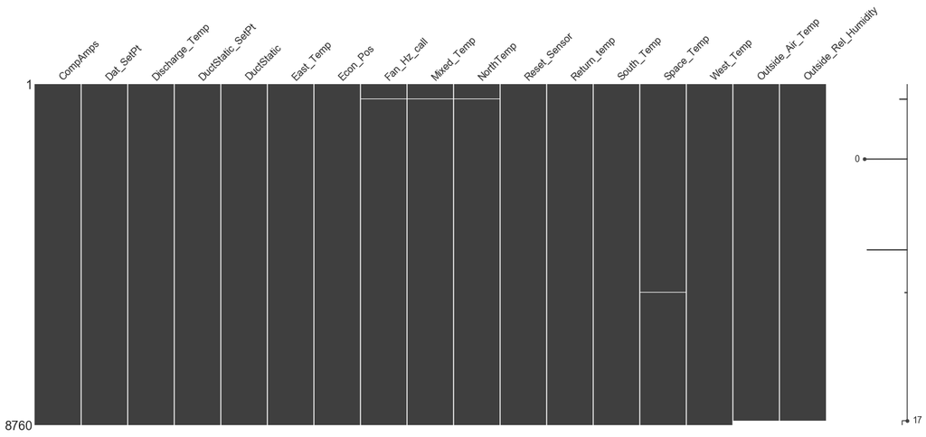

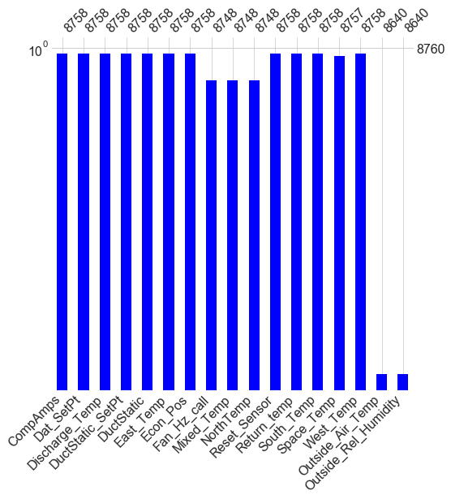

```python
#Exploring Data Missingness
#missing data patterns
#The missingno bar chart is a visualization of the data nullity.
#We log transformed the data on the y-axis to better visualize features with very large missing values.
#created a plot of the missing value matrix.
#created a plot of the missing value matrix.
missingdata_df = df1.columns[df1.isnull().any()].tolist()
msno.matrix(df1[missingdata_df])
msno.bar(df1[missingdata_df], color="blue", log=True, figsize=(8,8))
```

#### The missing number correlation heatmap generated below shows the measure of nullity correlation between the different attributes. The attributes that have a perfect positive nullity correlation of 1 between two features indicate that the first and second features have missing values while -1 indicates one feature has missing values while the other doesnt.

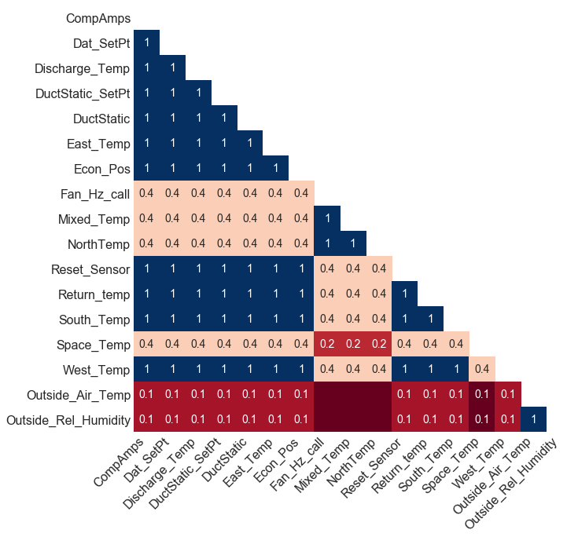

```python
msno.heatmap(df1[missingdata_df], figsize=(10,10))
#This map describes the degree of nullity relationship between the different features.
#The range of this nullity correlation is from -1 to 1 (-1 ≤ R ≤ 1). Features with no missing value are excluded in the heatmap.
#If the nullity correlation is very close to zero (-0.05 < R < 0.05), no value will be displayed.
#Also, a perfect positive nullity correlation (R=1) indicates when the first feature and the second feature both have corresponding missing values
#while a perfect negative nullity correlation (R=-1)means that one of the features is missing and the second is not missing.
```

#### The number of missing values in the dataset is 301

```python
df1.isnull().sum().sum()
```

```
301
```

#### Dropping the rows with missing values returns a dataframe of 8628 records

```python
df2 = df1.dropna()
len(df2)
#df2.to_csv('D:/Capstone/Cleaned files/test1.csv')
```

```
8628
```

```python
#Summary Statistics for West Temp
df2.describe()
```

|  | CompAmps | Dat_SetPt | Discharge_Temp | DuctStatic_SetPt | DuctStatic | East_Temp | Econ_Pos | Fan_Hz_call | Mixed_Temp | NorthTemp | Reset_Sensor | Return_temp | South_Temp | Space_Temp | West_Temp | Outside_Air_Temp | Outside_Rel_Humidity |
| --- | --- | --- | --- | --- | --- | --- | --- | --- | --- | --- | --- | --- | --- | --- | --- | --- | --- |
| count | 8628.000000 | 8628.000000 | 8628.000000 | 8628.000000 | 8628.000000 | 8628.000000 | 8628.000000 | 8628.000000 | 8628.000000 | 8628.000000 | 8628.000000 | 8628.000000 | 8628.000000 | 8628.000000 | 8628.000000 | 8628.000000 | 8628.000000 |
| mean | 8.863236 | 62.934064 | 67.942791 | 1.110918 | 0.515296 | 73.096674 | 8.405656 | 32.662958 | 72.160825 | 73.763004 | 73.616632 | 71.505621 | 73.632707 | 73.706328 | 74.395735 | 61.852167 | 75.369726 |
| std | 19.585749 | 7.706393 | 7.046876 | 0.124211 | 0.508954 | 3.007404 | 22.424636 | 15.603459 | 5.047256 | 3.085651 | 2.947234 | 5.008070 | 2.388066 | 2.925835 | 4.391499 | 17.539015 | 21.894275 |
| min | 0.000000 | 55.000000 | 45.000000 | 1.000000 | 0.060000 | 61.200000 | 0.000000 | 20.000000 | 50.000000 | 61.800000 | 62.700000 | 50.800000 | 64.900000 | 62.700000 | 59.900000 | 17.400000 | 0.200000 |
| 25% | 0.000000 | 55.600000 | 62.400000 | 1.000000 | 0.090000 | 71.100000 | 0.000000 | 20.000000 | 69.300000 | 72.000000 | 72.200000 | 69.200000 | 72.100000 | 72.200000 | 71.500000 | 47.700000 | 61.000000 |
| 50% | 0.000000 | 59.900000 | 69.400000 | 1.000000 | 0.090000 | 72.900000 | 0.000000 | 20.000000 | 73.100000 | 74.400000 | 73.500000 | 72.200000 | 73.400000 | 73.500000 | 74.000000 | 62.000000 | 78.500000 |
| 75% | 0.000000 | 72.000000 | 73.100000 | 1.250000 | 1.020000 | 75.100000 | 5.000000 | 46.000000 | 75.700000 | 75.500000 | 75.400000 | 74.500000 | 75.200000 | 75.500000 | 77.900000 | 75.900000 | 96.600000 |
| max | 90.000000 | 80.000000 | 83.200000 | 1.250000 | 1.540000 | 80.300000 | 100.000000 | 68.000000 | 85.800000 | 80.200000 | 82.400000 | 84.500000 | 80.500000 | 80.200000 | 87.700000 | 104.200000 | 100.000000 |

#### Measuring the skewness of the dataset results in the table below where it is seen that attribute economizer_position has the highest skewness value of 3.34 followed by compamps with a skewness of 1.826. The rest of the attributes have their skewness values between -3 and 3.

```python
#skewness
df_skew = df2[['CompAmps','Dat_SetPt','Discharge_Temp','DuctStatic_SetPt','DuctStatic','East_Temp','Econ_Pos','Fan_Hz_call',
                 'Mixed_Temp','NorthTemp','Reset_Sensor','Return_temp','South_Temp','Space_Temp','West_Temp','Outside_Air_Temp',
                 'Outside_Rel_Humidity']]
df_skew.skew()
```

```
CompAmps                1.826474
Dat_SetPt               0.554020
Discharge_Temp         -0.448476
DuctStatic_SetPt        0.226796
DuctStatic              0.399252
East_Temp              -0.108577
Econ_Pos                3.340700
Fan_Hz_call             0.623073
Mixed_Temp             -0.778414
NorthTemp              -0.690632
Reset_Sensor           -0.139713
Return_temp            -0.940423
South_Temp              0.078378
Space_Temp             -0.214140
West_Temp              -0.120090
Outside_Air_Temp       -0.002868
Outside_Rel_Humidity   -0.687797
dtype: float64
```

#### Measuring the kurtosis values of the AHU dataset shows that while a few of the attributes have kurtosis values greater than 1 and -1, most of the attributes are between 1 and -1.

```python
df_skew.kurtosis()
```

```
CompAmps                1.546067
Dat_SetPt              -1.287375
Discharge_Temp         -0.644333
DuctStatic_SetPt       -1.949015
DuctStatic             -1.716855
East_Temp               0.337545
Econ_Pos               -1.781747
Fan_Hz_call            -1.199498
Mixed_Temp              0.479754
NorthTemp               0.616118
Reset_Sensor            0.527180
Return_temp             1.511598
South_Temp              0.280288
Space_Temp              0.403434
West_Temp              -0.488180
Outside_Air_Temp       -0.843606
Outside_Rel_Humidity   -0.266827
dtype: float64
```

```python
#used the quantile() method on the df, and specified the quantile to see for the specified column
df2.quantile([.05, .1, .25, .5, .75, .9, .99])
```

|  | CompAmps | Dat_SetPt | Discharge_Temp | DuctStatic_SetPt | DuctStatic | East_Temp | Econ_Pos | Fan_Hz_call | Mixed_Temp | NorthTemp | ... | West_Temp | Outside_Air_Temp | Outside_Rel_Humidity | CompRelayStatus | Loader2Status | SupplyFanStatus | VAVEnableRelayStatus | VAVHeatEnableStatus | Loader1sTATUS | UnoccupiedLimit |
| --- | --- | --- | --- | --- | --- | --- | --- | --- | --- | --- | --- | --- | --- | --- | --- | --- | --- | --- | --- | --- | --- |
| 0.05 | 0.0 | 55.0 | 55.1 | 1.00 | 0.07 | 68.5 | 0.0 | 20.0 | 62.2 | 67.9 | ... | 66.8 | 34.100 | 34.8 | 0.0 | 0.0 | 0.0 | 0.0 | 0.0 | 0.0 | 0.0 |
| 0.10 | 0.0 | 55.0 | 57.6 | 1.00 | 0.08 | 69.9 | 0.0 | 20.0 | 64.8 | 69.4 | ... | 68.6 | 38.700 | 43.7 | 0.0 | 0.0 | 0.0 | 0.0 | 0.0 | 0.0 | 0.0 |
| 0.25 | 0.0 | 55.6 | 62.4 | 1.00 | 0.09 | 71.1 | 0.0 | 20.0 | 69.3 | 72.0 | ... | 71.5 | 47.700 | 61.0 | 0.0 | 0.0 | 0.0 | 0.0 | 0.0 | 0.0 | 0.0 |
| 0.50 | 0.0 | 59.9 | 69.4 | 1.00 | 0.09 | 72.9 | 0.0 | 20.0 | 73.1 | 74.4 | ... | 74.0 | 62.000 | 78.5 | 0.0 | 0.0 | 0.0 | 0.0 | 0.0 | 0.0 | 0.0 |
| 0.75 | 0.0 | 72.0 | 73.1 | 1.25 | 1.02 | 75.1 | 5.0 | 46.0 | 75.7 | 75.5 | ... | 77.9 | 75.900 | 96.6 | 0.0 | 0.0 | 1.0 | 1.0 | 0.0 | 0.0 | 0.0 |
| 0.90 | 47.0 | 75.0 | 76.5 | 1.25 | 1.24 | 77.3 | 17.0 | 55.0 | 77.9 | 77.5 | ... | 80.4 | 85.100 | 100.0 | 1.0 | 0.0 | 1.0 | 1.0 | 1.0 | 0.0 | 0.0 |
| 0.99 | 62.0 | 78.0 | 80.1 | 1.25 | 1.34 | 79.5 | 100.0 | 65.0 | 80.7 | 79.5 | ... | 82.8 | 96.673 | 100.0 | 1.0 | 0.0 | 1.0 | 1.0 | 1.0 | 1.0 | 0.0 |

7 rows × 24 columns

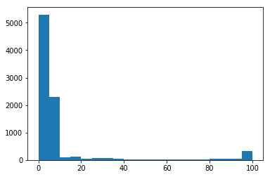

```python
plt.hist(df_skew['Econ_Pos'], bins=20)
plt.show()
```

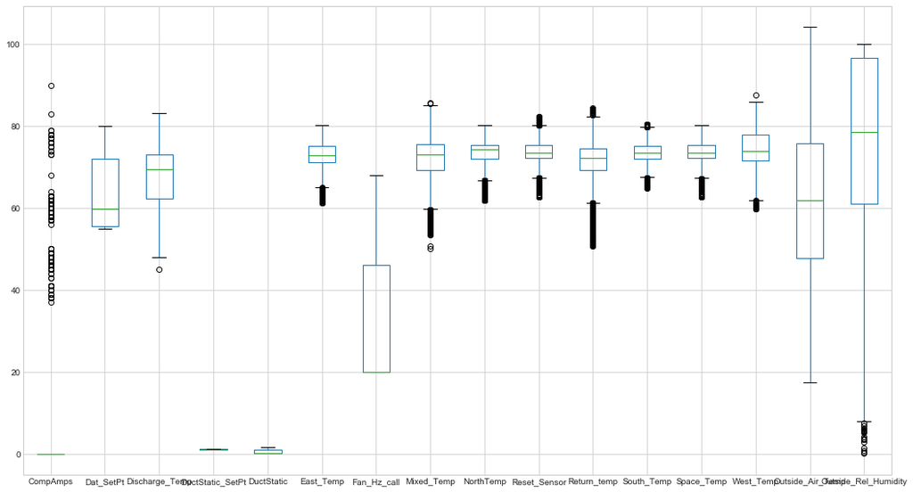

```python
#sns.set_style("whitegrid")
#sns.boxplot(data=df_skew )
df_skew.plot.box(return_type='axes', figsize=(18,10))
```

#### The statistics below show the inter quartile range, max and min values and identified outliers for the discharge temp, outside relative humidity and economizer position attributes.

```python
q75, q25 = np.percentile(df2.Discharge_Temp, [75 ,25])
iqr = q75 - q25
max = q75 + (iqr*1.5)
min = q25 - (iqr*1.5)
print('iqr: %d' % iqr)
print('max: %d' % max)
print ('min: %d' % min)
# identify outliers
outliers = [x for x in df2['Discharge_Temp'] if x < min or x > max]
print('Identified outliers: %d' % len(outliers))
```

```
iqr: 10
max: 89
min: 46
Identified outliers: 1
```

```python
q75, q25 = np.percentile(df2.Outside_Rel_Humidity, [75 ,25])
iqr = q75 - q25
max = q75 + (iqr*1.5)
min = q25 - (iqr*1.5)
print('iqr: %d' % iqr)
print('max: %d' % max)
print ('min: %d' % min)
# identify outliers
outliers = [x for x in df2['Outside_Rel_Humidity'] if x < min or x > max]
print('Identified outliers: %d' % len(outliers))
```

```
iqr: 35
max: 150
min: 7
Identified outliers: 20
```

```python
q75, q25 = np.percentile(df2.Econ_Pos, [75 ,25])
print('q75: %d' % q75)
print('q25: %d' % q25)
iqr = q75 - q25
max = q75 + (iqr*1.5)
min = q25 - (iqr*1.5)
print('iqr: %d' % iqr)
print('max: %d' % max)
print ('min: %d' % min)
# identify outliers
outliers = [x for x in df2['Econ_Pos'] if x < min or x > max]
print('Identified outliers: %d' % len(outliers))
```

```
q75: 5
q25: 0
iqr: 5
max: 12
min: -7
Identified outliers: 979
```

#### The plot below shows the decomposition of the discharge temp attribute from the AHU data into trend, seasonal and residual components. From the trend plot, it is seen that the discharge temperature has a significant drop during the month of December. The decomposition frequency is taken as 7 days ie 1 week. The Observed plot is from the original data, seasonal is the repetition within the frequency, trend shows the pattern/trend while residual is everything that is not described by seasonal or trend.

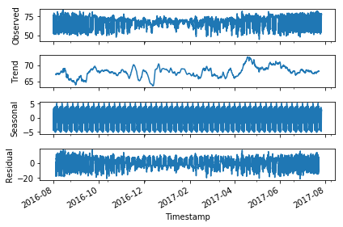

```python
#weekly wise
#Evaluation of the TimeSeries Decomposition
#We are taking the decomposition frequency as 7 days
#Seasonal Decomposition of the data: Observed is the original data, seasonal is the repetition within freq,
#trend is the trend and residual is everything, which is not described by seasonal+trend

import statsmodels.api as sm
decompfreq = 7*24
res = sm.tsa.seasonal_decompose(df2.Discharge_Temp.interpolate(),
 freq=decompfreq, model='additive')
resplot = res.plot()
#result = seasonal_decompose(series, model='additive', frequency = )
#result.plot()
#pyplot.show()
```

#### The plot below consists of the discharge temp, east temp, mixed temp, north temp, return temp, south temp, space temp and west temp attributes plotted against time. The plot shows that all of these temperature values follow a similar pattern with seasonal variations.

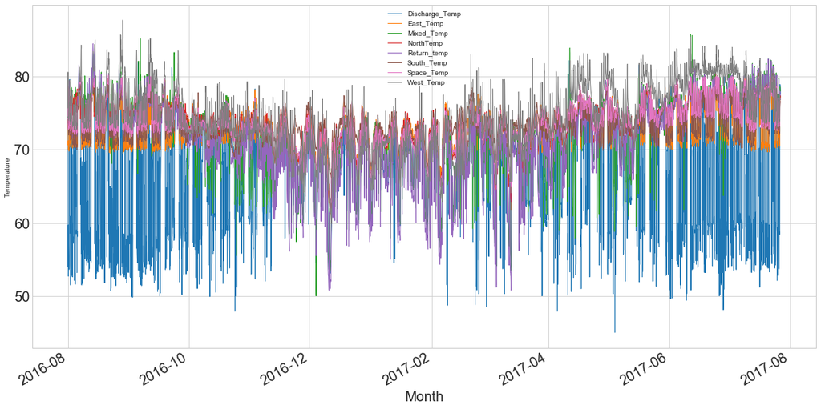

```python
df_temp = df2[['Discharge_Temp','East_Temp','Mixed_Temp','NorthTemp','Return_temp','South_Temp','Space_Temp','West_Temp']]
df_temp.plot(figsize=(20,10), linewidth=1, fontsize=20)
plt.xlabel('Month', fontsize=20);
plt.ylabel( 'Temperature');
```

#### The plot below shows the relation between outside air temp and discharge temperature.

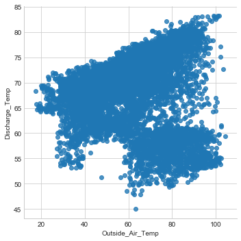

```python
sns.lmplot(x='Outside_Air_Temp', y='Discharge_Temp', fit_reg=False, data=df2);
#df2.plot(x = 'Outside_Air_Temp', y ='Discharge_Temp', style=['o','rx'])
```

#### The figure belows shows how the different temperature measurements within the space of the building follow similar patterns throughout the year. The green line indicates the outside air temperature that varies based on the season. On the other hand, the discharge temperature ( dotted blue) follows an almost constant value throughout the year indicating the constant temperature that needs to be maintained inside the building irrespective of weather.

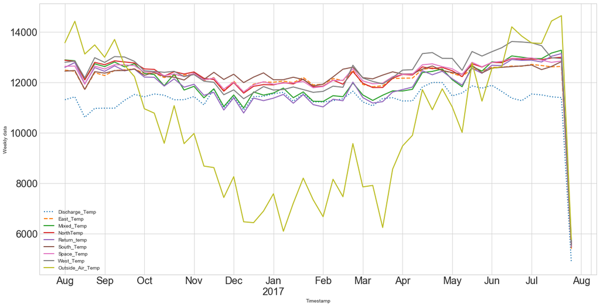

```python
df_all_temp = df2[['Discharge_Temp','East_Temp','Mixed_Temp','NorthTemp','Return_temp','South_Temp','Space_Temp','West_Temp', 'Outside_Air_Temp',]]
weekly = df_all_temp.resample('W').sum()
weekly.plot(style=[':', '--', '-'], figsize=(20,10), linewidth= 2, fontsize=20)
plt.ylabel('Weekly data');
```

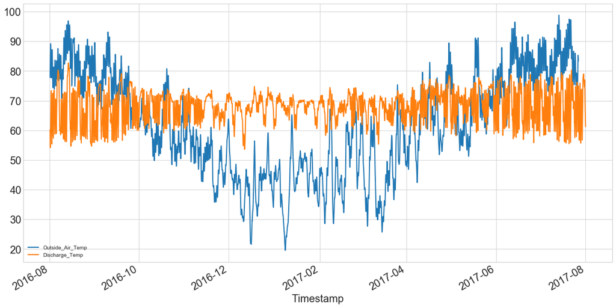

```python
df_rm = pd.concat([df2.Outside_Air_Temp.rolling(12).mean(), df1.Discharge_Temp.rolling(12).mean()], axis=1)
df_rm.plot(figsize=(20,10), linewidth=2, fontsize=20)
plt.xlabel('Timestamp', fontsize=20);
```

#### The density plot of outside air temp and discharge temp shows that the discharge temp remains constant throughout the year in order to maintain stable temperatures within the building while the outside air temp varies seasonally through the year.

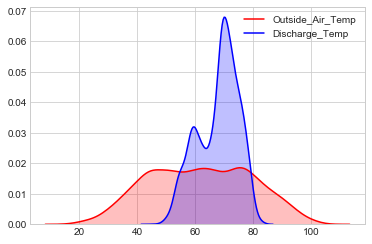

```python
p1=sns.kdeplot(df2['Outside_Air_Temp'], shade=True, color="r")
p1=sns.kdeplot(df2['Discharge_Temp'], shade=True, color="b")
#This shows that the discharge temp remains constant and does not change with the varying outside temp.
```

#### Scatter plots have been plotted for the discharge, return , space, outside air and mixed temperature attributes.

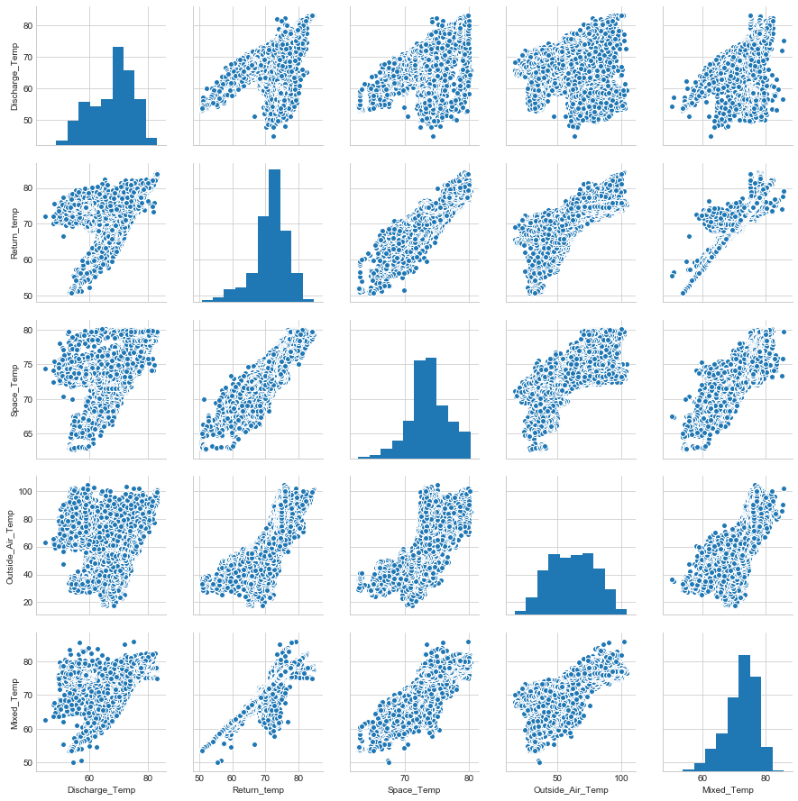

```python
df_temp_1 = df2[['Discharge_Temp','Return_temp','Space_Temp', 'Outside_Air_Temp', 'Mixed_Temp']]
sns.pairplot(df_temp_1, kind="scatter")
plt.show()
```

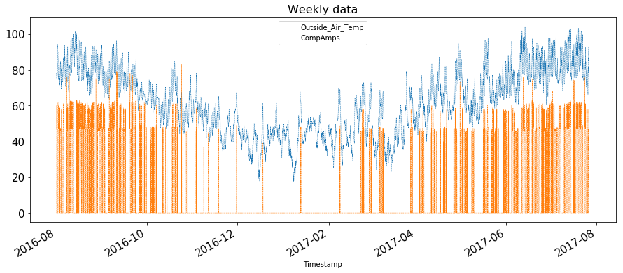

```python
df3 = df2[['Outside_Air_Temp', 'CompAmps',]]
weeklydf = df3.asfreq('W', how='sume', normalize=False)

plt.figure()
fig = df3['2016-08':'2017-07'].plot(figsize = (15, 6), fontsize = 15, linestyle='--' ,linewidth= 0.5)
fig.set_axis_bgcolor('w')
plt.title('Weekly data', fontsize = 16)
plt.ylabel('')
ax = plt.gca()
plt.show()
```

#### Rolling mean calculation with window size of 12. Below graph shows the trend for 5 temperatures (East, West, South, North and Space). These temperature observations show similar trends

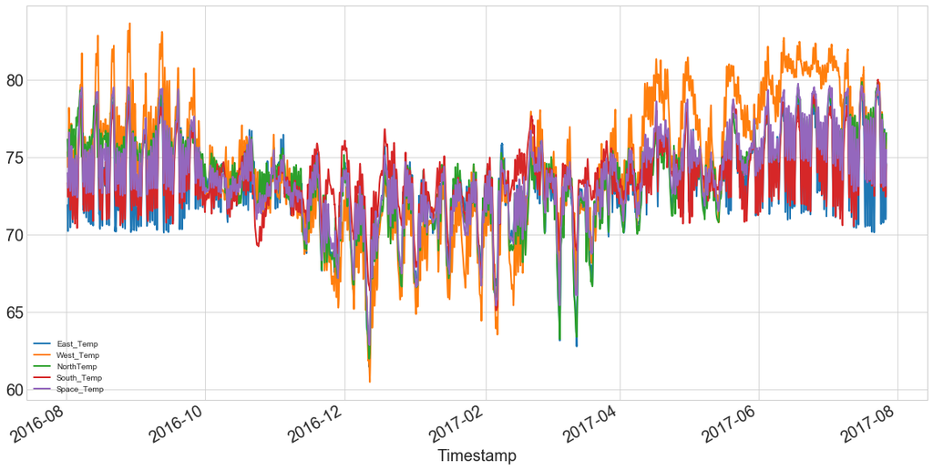

```python
#rolling mean calculations with window sizes of 12
df_rm = pd.concat([df2.East_Temp.rolling(12).mean(), df2.West_Temp.rolling(12).mean(), df2.NorthTemp.rolling(12).mean(),df2.South_Temp.rolling(12).mean(), df2.Space_Temp.rolling(12).mean()], axis=1)
df_rm.plot(figsize=(20,10), linewidth=2, fontsize=20)
plt.xlabel('Timestamp', fontsize=20);
```

#### Below are the scatter plots

#### 1 ) Between Discharge Temp and DuctSatic 2) Between Discharge Temp and CompAmps

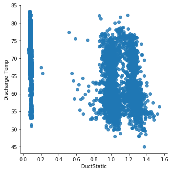

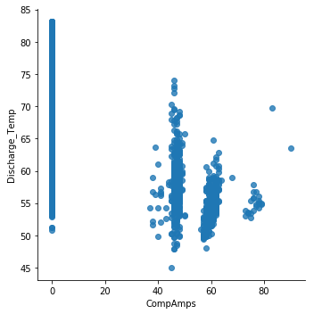

```python
sns.lmplot(x='DuctStatic', y='Discharge_Temp', fit_reg=False, data=df2);
sns.lmplot(x='CompAmps', y='Discharge_Temp', fit_reg=False, data=df2);
```

#### Below is the correlation matrix of the data

```python
corr = df2.corr()
corr
```

|  | CompAmps | Dat_SetPt | Discharge_Temp | DuctStatic_SetPt | DuctStatic | East_Temp | Econ_Pos | Fan_Hz_call | Mixed_Temp | NorthTemp | ... | West_Temp | Outside_Air_Temp | Outside_Rel_Humidity | CompRelayStatus | Loader2Status | SupplyFanStatus | VAVEnableRelayStatus | VAVHeatEnableStatus | Loader1sTATUS | UnoccupiedLimit |
| --- | --- | --- | --- | --- | --- | --- | --- | --- | --- | --- | --- | --- | --- | --- | --- | --- | --- | --- | --- | --- | --- |
| CompAmps | 1.000000 | -0.304739 | -0.704332 | 0.063222 | 0.540003 | -0.243664 | 0.129706 | 0.609188 | 0.247705 | 0.235713 | ... | 0.214591 | 0.468359 | -0.233810 | 0.716369 | 0.163633 | 0.467496 | 0.526638 | -0.189178 | 0.524833 | 0.183449 |
| Dat_SetPt | -0.304739 | 1.000000 | -0.063043 | -0.263854 | 0.085434 | -0.475815 | -0.113432 | -0.010108 | -0.614623 | -0.704087 | ... | -0.709168 | -0.793277 | 0.290276 | -0.197600 | -0.053504 | 0.209324 | 0.101584 | 0.471937 | -0.167615 | -0.069977 |
| Discharge_Temp | -0.704332 | -0.063043 | 1.000000 | 0.084748 | -0.507921 | 0.686180 | -0.220218 | -0.504615 | 0.381396 | 0.272840 | ... | 0.236200 | 0.000689 | 0.119061 | -0.495821 | -0.085858 | -0.513732 | -0.492433 | 0.025493 | -0.376182 | -0.099452 |
| DuctStatic_SetPt | 0.063222 | -0.263854 | 0.084748 | 1.000000 | 0.081305 | 0.215338 | 0.007232 | 0.105923 | 0.238891 | 0.244263 | ... | 0.468231 | 0.273346 | -0.110230 | 0.221813 | 0.006233 | -0.053194 | -0.020321 | -0.119829 | 0.026380 | 0.027768 |
| DuctStatic | 0.540003 | 0.085434 | -0.507921 | 0.081305 | 1.000000 | -0.263975 | 0.349278 | 0.941337 | 0.033514 | 0.136954 | ... | 0.067109 | 0.068299 | -0.111129 | 0.449797 | 0.053940 | 0.797338 | 0.983769 | 0.500371 | 0.234227 | 0.049803 |
| East_Temp | -0.243664 | -0.475815 | 0.686180 | 0.215338 | -0.263975 | 1.000000 | -0.066807 | -0.223216 | 0.731854 | 0.807662 | ... | 0.708097 | 0.477408 | -0.086189 | -0.154641 | 0.004350 | -0.361726 | -0.258797 | -0.079078 | -0.099135 | 0.053159 |
| Econ_Pos | 0.129706 | -0.113432 | -0.220218 | 0.007232 | 0.349278 | -0.066807 | 1.000000 | 0.336166 | -0.140041 | 0.071469 | ... | 0.052752 | 0.042067 | -0.194427 | 0.112694 | 0.085950 | 0.285973 | 0.346399 | 0.048670 | 0.071608 | 0.006469 |
| Fan_Hz_call | 0.609188 | -0.010108 | -0.504615 | 0.105923 | 0.941337 | -0.223216 | 0.336166 | 1.000000 | 0.103749 | 0.180204 | ... | 0.155291 | 0.198859 | -0.161927 | 0.513769 | 0.086975 | 0.757905 | 0.926092 | 0.364188 | 0.282631 | 0.111466 |
| Mixed_Temp | 0.247705 | -0.614623 | 0.381396 | 0.238891 | 0.033514 | 0.731854 | -0.140041 | 0.103749 | 1.000000 | 0.835624 | ... | 0.742290 | 0.729879 | -0.198448 | 0.182509 | 0.057281 | -0.117865 | 0.034615 | -0.165918 | 0.146187 | 0.083123 |
| NorthTemp | 0.235713 | -0.704087 | 0.272840 | 0.244263 | 0.136954 | 0.807662 | 0.071469 | 0.180204 | 0.835624 | 1.000000 | ... | 0.853611 | 0.778750 | -0.252793 | 0.171710 | 0.060076 | -0.038483 | 0.136717 | -0.133678 | 0.126232 | 0.102797 |
| Reset_Sensor | 0.060445 | -0.640099 | 0.438246 | 0.313514 | -0.053226 | 0.879914 | -0.019818 | 0.018092 | 0.818666 | 0.913073 | ... | 0.867934 | 0.709607 | -0.271351 | 0.087051 | 0.048839 | -0.207810 | -0.063208 | -0.157323 | 0.066308 | 0.102347 |
| Return_temp | 0.196724 | -0.669620 | 0.369638 | 0.279101 | 0.075950 | 0.783021 | 0.025718 | 0.146375 | 0.927354 | 0.885505 | ... | 0.783093 | 0.750689 | -0.198734 | 0.165440 | 0.047737 | -0.096201 | 0.067652 | -0.147729 | 0.114617 | 0.082061 |
| South_Temp | -0.244391 | -0.348690 | 0.611997 | 0.281938 | -0.321611 | 0.869865 | -0.181000 | -0.274921 | 0.600789 | 0.677794 | ... | 0.634336 | 0.390524 | -0.104171 | -0.162759 | 0.043168 | -0.412151 | -0.318783 | -0.093025 | -0.063361 | 0.118879 |
| Space_Temp | 0.028126 | -0.644223 | 0.463710 | 0.353288 | -0.063789 | 0.912620 | -0.013799 | 0.003308 | 0.813601 | 0.925775 | ... | 0.910595 | 0.700697 | -0.251782 | 0.054300 | 0.043824 | -0.229144 | -0.073547 | -0.150640 | 0.037332 | 0.108742 |
| West_Temp | 0.214591 | -0.709168 | 0.236200 | 0.468231 | 0.067109 | 0.708097 | 0.052752 | 0.155291 | 0.742290 | 0.853611 | ... | 1.000000 | 0.778827 | -0.384533 | 0.219289 | 0.047918 | -0.119682 | 0.033182 | -0.238357 | 0.114524 | 0.110603 |
| Outside_Air_Temp | 0.468359 | -0.793277 | 0.000689 | 0.273346 | 0.068299 | 0.477408 | 0.042067 | 0.198859 | 0.729879 | 0.778750 | ... | 0.778827 | 1.000000 | -0.409431 | 0.333677 | 0.064751 | -0.052459 | 0.049798 | -0.476321 | 0.248793 | 0.098791 |
| Outside_Rel_Humidity | -0.233810 | 0.290276 | 0.119061 | -0.110230 | -0.111129 | -0.086189 | -0.194427 | -0.161927 | -0.198448 | -0.252793 | ... | -0.384533 | -0.409431 | 1.000000 | -0.134819 | -0.061922 | -0.072226 | -0.108477 | 0.144756 | -0.157402 | -0.066926 |
| CompRelayStatus | 0.716369 | -0.197600 | -0.495821 | 0.221813 | 0.449797 | -0.154641 | 0.112694 | 0.513769 | 0.182509 | 0.171710 | ... | 0.219289 | 0.333677 | -0.134819 | 1.000000 | 0.085319 | 0.350573 | 0.395888 | -0.143710 | 0.345528 | 0.103718 |
| Loader2Status | 0.163633 | -0.053504 | -0.085858 | 0.006233 | 0.053940 | 0.004350 | 0.085950 | 0.086975 | 0.057281 | 0.060076 | ... | 0.047918 | 0.064751 | -0.061922 | 0.085319 | 1.000000 | 0.057268 | 0.063977 | -0.013798 | 0.186274 | 0.352297 |
| SupplyFanStatus | 0.467496 | 0.209324 | -0.513732 | -0.053194 | 0.797338 | -0.361726 | 0.285973 | 0.757905 | -0.117865 | -0.038483 | ... | -0.119682 | -0.052459 | -0.072226 | 0.350573 | 0.057268 | 1.000000 | 0.805970 | 0.376136 | 0.209035 | 0.074578 |
| VAVEnableRelayStatus | 0.526638 | 0.101584 | -0.492433 | -0.020321 | 0.983769 | -0.258797 | 0.346399 | 0.926092 | 0.034615 | 0.136717 | ... | 0.033182 | 0.049798 | -0.108477 | 0.395888 | 0.063977 | 0.805970 | 1.000000 | 0.529509 | 0.233521 | 0.083314 |
| VAVHeatEnableStatus | -0.189178 | 0.471937 | 0.025493 | -0.119829 | 0.500371 | -0.079078 | 0.048670 | 0.364188 | -0.165918 | -0.133678 | ... | -0.238357 | -0.476321 | 0.144756 | -0.143710 | -0.013798 | 0.376136 | 0.529509 | 1.000000 | -0.083343 | -0.023945 |
| Loader1sTATUS | 0.524833 | -0.167615 | -0.376182 | 0.026380 | 0.234227 | -0.099135 | 0.071608 | 0.282631 | 0.146187 | 0.126232 | ... | 0.114524 | 0.248793 | -0.157402 | 0.345528 | 0.186274 | 0.209035 | 0.233521 | -0.083343 | 1.000000 | 0.263987 |
| UnoccupiedLimit | 0.183449 | -0.069977 | -0.099452 | 0.027768 | 0.049803 | 0.053159 | 0.006469 | 0.111466 | 0.083123 | 0.102797 | ... | 0.110603 | 0.098791 | -0.066926 | 0.103718 | 0.352297 | 0.074578 | 0.083314 | -0.023945 | 0.263987 | 1.000000 |

24 rows × 24 columns

#### Dynamic Heatmap visualization using Pandas style.

#### Later, we will be using this heatmap and correlation for feature selection.

```python
cmap = cmap=sns.diverging_palette(5, 250, as_cmap=True)
def magnify_corr_matrix():
    return [dict(selector="th",
                 props=[("font-size", "7pt")]),
            dict(selector="td",
                 props=[('padding', "0em 0em")]),
            dict(selector="th:hover",
                 props=[("font-size", "12pt")]),
            dict(selector="tr:hover td:hover",
                 props=[('max-width', '200px'),
                        ('font-size', '12pt')])
]

corr.style.background_gradient(cmap, axis=1)\
    .set_properties(**{'max-width': '80px', 'font-size': '10pt'})\
    .set_caption("Hover to magify")\
    .set_precision(2)\
    .set_table_styles(magnify())
```

Hover to magify

[output not shown]

#### Below is the density plot showing the distribution of DuctStatic.

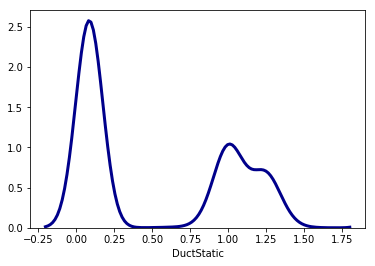

```python
sns.distplot(df2['DuctStatic'], hist=False, kde=True,
             bins=1, color = 'darkblue',
             hist_kws={'edgecolor':'black'},
             kde_kws={'linewidth': 3})
```

#### Below is the density plot showing the distribution of CompAmps which is showing multiple peaks

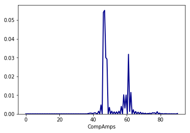

```python
sns.distplot(df2['CompAmps'], hist=False, kde=True,
             bins=1, color = 'darkblue',
             hist_kws={'edgecolor':'black'},
             kde_kws={'linewidth': 2})
```

#### Below is the density plot showing the distribution of Mixed Temp and Discharge Temp. Mixed Temp has higher peak value than the Discharge Temp

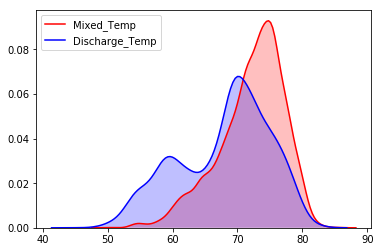

```python
p1=sns.kdeplot(df2['Mixed_Temp'], shade=True, color="r")
p1=sns.kdeplot(df2['Discharge_Temp'], shade=True, color="b")
#We can see that peak in the density plot for mixed temp is higher than Discharge_Temp
```

#### We can see how trend changes based on the time of the year. Below are the autocorrelation plots for the entire series and discharge temp and space temp.

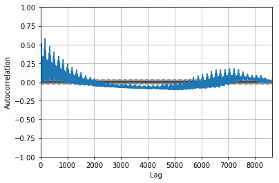

```python
from pandas.tools.plotting import autocorrelation_plot
from pandas import Series
from pandas import TimeGrouper
series = Series.from_csv('D:/Capstone/Cleaned files/test1.csv', header=0)
autocorrelation_plot(series)
plt.show()
```

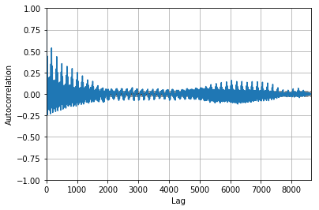

```python
Discharge_Temp = df2[['Discharge_Temp']]
pd.plotting.autocorrelation_plot(Discharge_Temp);
```

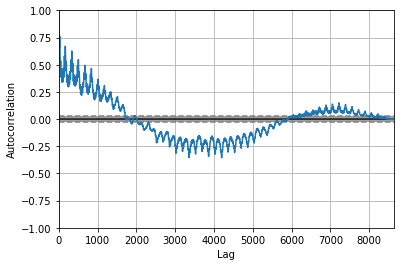

```python
Space_Temp = df2[['Space_Temp']]
pd.plotting.autocorrelation_plot(Space_Temp);
```